# From Scores to Lending Decisions

Risk Grades, Decision Support and Portfolio Trade-Offs

Evan Reynolds

2026-11-01

## Portfolio Summary

5

Risk grades

11%

Applicants in Grade 5

34%

Defaults in Grade 5

89%

Approval rate if Grade 5 excluded

**Excluding Grade 5 reduces the observed default rate from 8.6% to 6.4%.**

Base rates are labelled by population. 8.6% is the observed rate for the 50,349 in-policy test applicants used here. 8.07% is the rate across all 307,511 applications.

## From PD to Risk Grade

**Applicant data → Predicted PD → Risk grade (1 to 5) → Decision support**

Applicants are grouped into five risk grades based on predicted repayment difficulty. Grade 1 is the lowest risk and Grade 5 the highest.

**The model produces risk estimates and grades. It does not determine eligibility or make approval and decline decisions.**

## Default Rate by Risk Grade

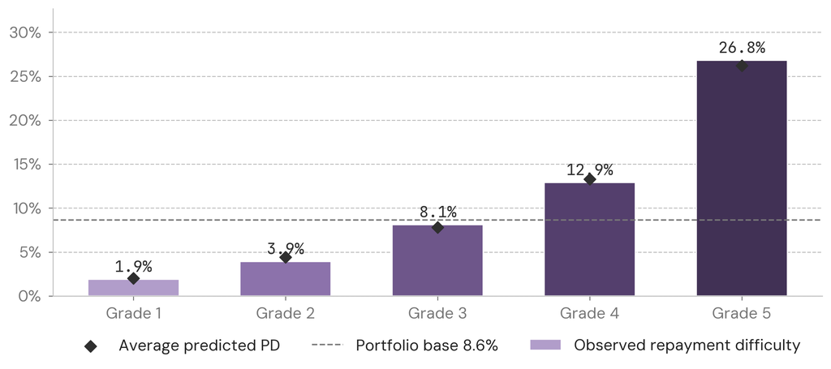

**Observed repayment difficulty rises from 1.9% in Grade 1 to 26.8% in Grade 5.**

## Where Defaults Are Concentrated

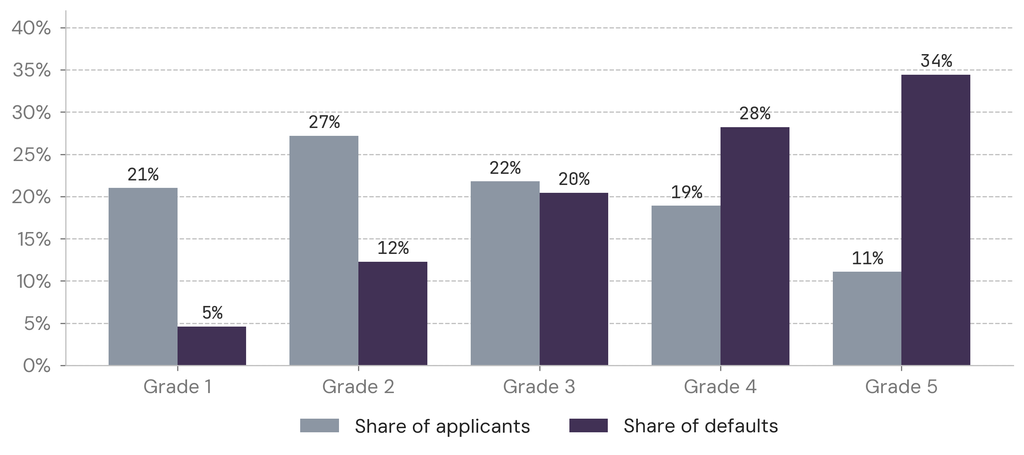

**Grade 5 holds 11% of applicants but 34% of observed defaults.**

## Cut-Off Trade-Offs

| Scenario | Approval rate | Defaults avoided | Approved default rate |
| --- | --- | --- | --- |
| All grades included | 100% | 0% | 8.6% |
| Exclude Grade 5 | 89% | 34% | 6.4% |
| Exclude Grades 4 to 5 | 70% | 63% | 4.6% |
| Exclude Grades 3 to 5 | 48% | 83% | 3.0% |
| Exclude Grades 2 to 5 | 21% | 95% | 1.9% |

Base: 8.6% observed default rate across 50,349 in-policy test applicants.

**Tighter cut-offs reduce observed default rates but also reduce approval rates.**

## Applicant Examples

[output not shown]

**Loan amount (500,000) and term (36 months) held constant.** LVR is the Credit-to-Goods Ratio. These examples can be recreated in the live applicant assessment tool.

## Decision Support by Risk Grade

| Grade | Risk level | Assessment path |
| --- | --- | --- |
| Grade 1 | Very low risk | Streamlined assessment |
| Grade 2 | Low risk | Standard assessment |
| Grade 3 | Moderate risk | Standard assessment |
| Grade 4 | Elevated risk | Additional assessment |
| Grade 5 | High risk | Refer or exclude under selected cut-off |

**Risk grade supports assessment. It does not replace affordability, eligibility, verification or credit policy.**

## Stakeholder Value

**Credit and Lending**

Consistent risk segmentation alongside affordability, policy and assessment.

**Portfolio Risk**

Visible risk concentration across grades and realised repayment outcomes.

**Management**

Clear approval-rate and portfolio-risk trade-offs under different cut-off scenarios.

**Model and Analytics**

Monitoring of grade distribution, realised outcomes and model performance over time.

## Model Limitations

**Population.** Observed applicants only. No reject inference.

**Cut-off analysis.** No loss or margin data. Cut-offs show risk trade-offs, not profit optimisation.

**Calibration.** PD estimates have not undergone formal calibration.

**Data.** Based on anonymised Home Credit data, not a specific Australian lending portfolio.

## From Model to Decision Support

The final scorecard separates applicants into distinct risk grades that can support consistent credit assessment and portfolio decision-making.

The model supports lending judgement. It does not replace affordability, eligibility, verification or credit policy.